# Plant Taxonomy

## What is a Plant? A Traditional View

- **Plants are characterized by their characters & character states**
  - green
  - non-motile
  - eukaryotic & multi-cellular
  - cell walls of cellulose
  - alternation of generations

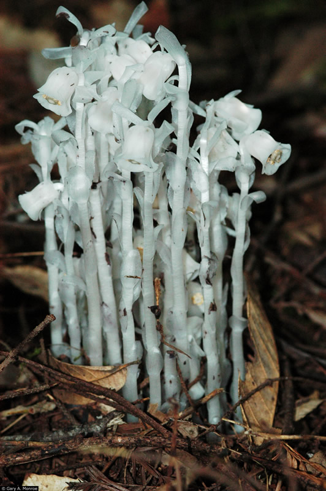

## What is a Plant? A Traditional View

- **Plants are characterized by their characters & character states**
  - green
  - non-motile
  - eukaryotic & multi-cellular
  - cell walls of cellulose
  - alternation of generations
- **Diversity: There are many kinds of plants and hundreds of thousands of species**
  - but the basic lineages of plants are fairly easy
  - new characters define evolution of lineages

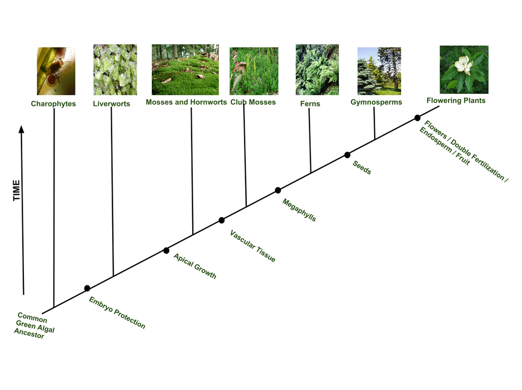

## Taxonomy

- **Classification is putting organisms into groups**
  - requires naming, describing, and identifying species
- **Linnaeus founded binomial system and classification hierarchy**
  - *King Phillip Came Over From Germany Stoned*
  - each level or unit is called a *taxon*
    - a group of any rank in the system
- **Kingdom is the most inclusive group, species is the least inclusive**
  - traditionally, placement into a taxon was determined by character traits
  - now, these taxa are being defined via molecular markers

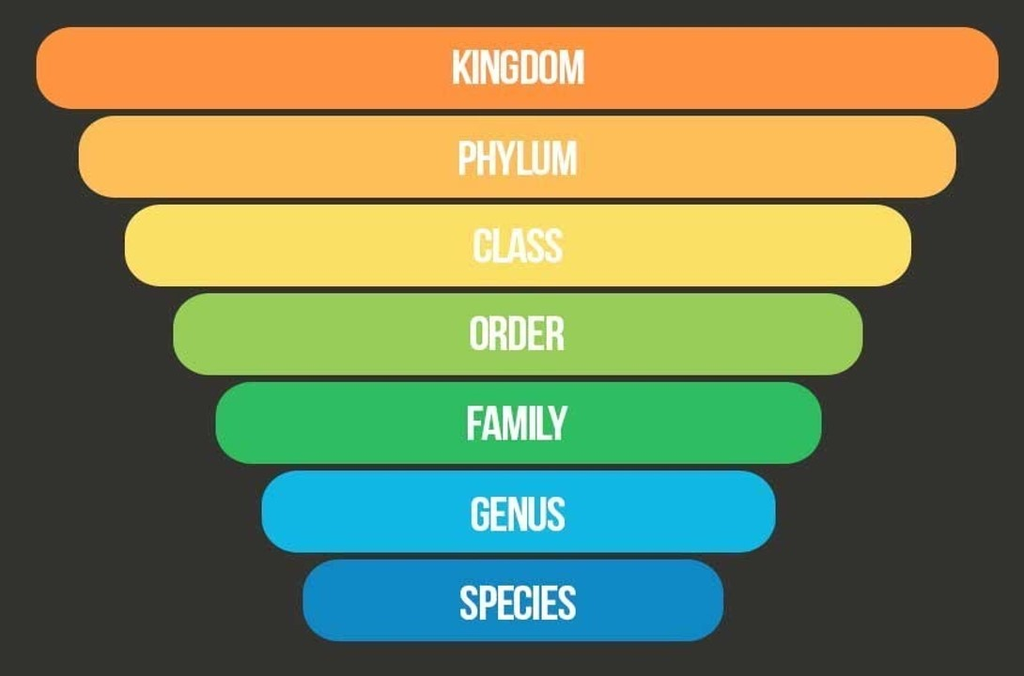

## Taxonomy has predictive value…

- **Question: If two plants are related (i.e., in the same taxon) and one of the plants is a source of food or potential drug, what can we assume about the second plant?**
- **Case Study: Pacific yew (*Taxus brevifolia*)**
  - Taxol: alkaloid first isolated from the bark and used to treat breast cancer
  - FDA approval in 1994 but the bark of 3 trees is needed for 1 patient
  - 16,000 pounds of bark is used to produce 2.2 pounds of taxol
- **Search for taxol was successful in other members of the genus**
  - has made drug more available

[figure not shown]

## Nomenclature should have value to the reader…

[figure not shown]

[figure not shown]

## Common names vs Scientific nomenclature

- **Common names have the following advantages:**
  - often descriptive (i.e., describe some important feature)
  - easy to pronounce & remember (more familiar to people)
  - more pleasing to hear & some are fun
- **Common names have some disadvantages:**
  - not governed by rules, so little consistency
  - applied indiscriminately to various taxonomic levels (i.e. ‘Oak’)
  - some plants have more than one common name
  - may not exists for rare species
  - may reflect language barriers
  - may be botanically incorrect (e.g. Jerusalem artichoke)

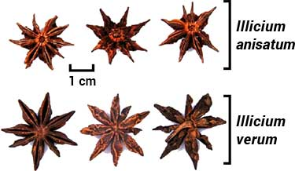

## Common names vs Scienitific nomenclature

- **The rule book for botanical nomenclature is the International Code of Botanical Nomenclature (ICBN)**
  - every plant gets 1 binomial name
  - Binomials are *genus* name + *specific epithet* (e.g. *Quercus rubra*)
- **Genus names are nouns that may commemorate a place, person, person, habitat, culture**
- **Epithets are adjectives that can also be commemorative (except for the name of the discoverer)**
- **Taxonomic ranks have standardized endings**

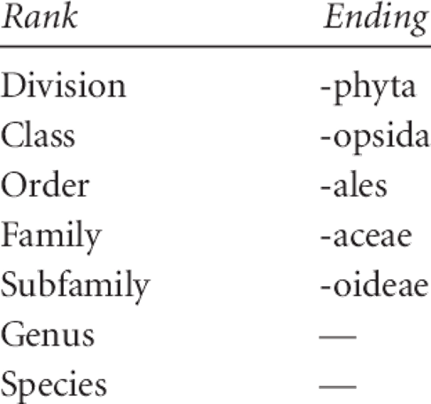

## Identifying a species usually requires a dichotmous key

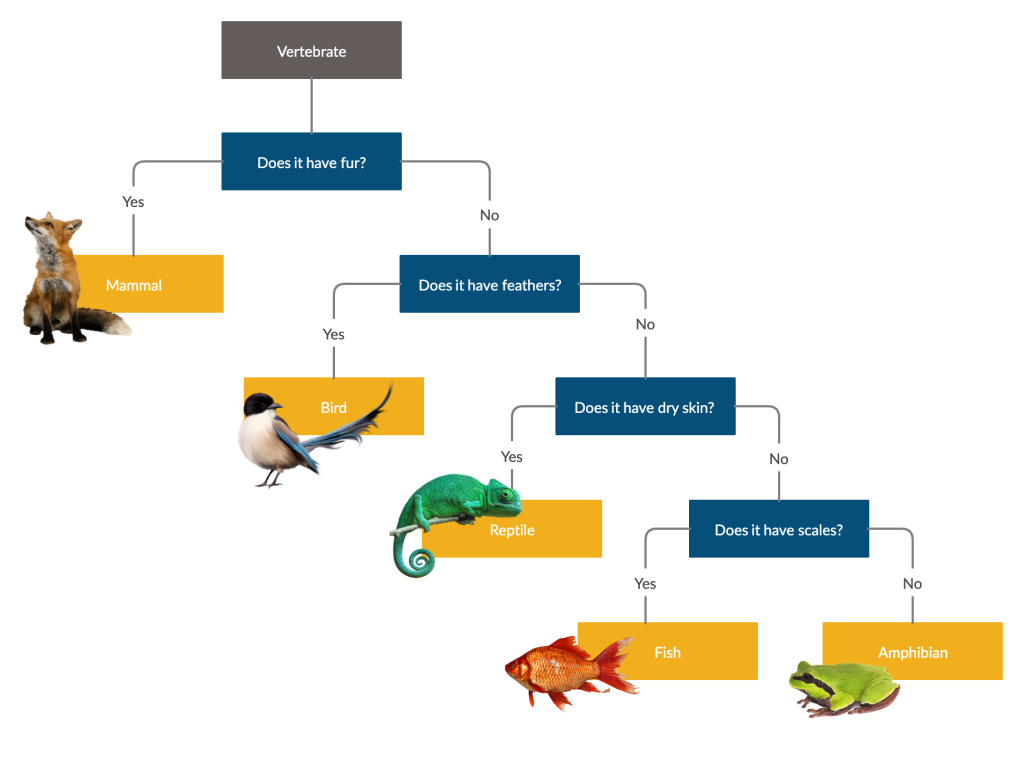

- **Keys consists of paired questions (‘couplets’)**
  - resembles choose your own adventure books
  - choose the statement that fits your specimen
  - guides you forward through selection steps
- **We will need to bypass this process in this class**
  - we will utilize online tools that help
  - phone apps and interactive keys
- **I DO want you to learn major diagnostic characters**

## We must learn vegetative terminology!!

- **The amount of terminology used in Plant Taxonomy may, at times, seem overwhelming**
- **A feature/trait of a plant is called a *character* and the specific form of the character is a *state*.**
  - example: leaf margins are single-toothed
  - you need many states to ID a plant
- **These diagnostic characters cover all aspects of plant morphology**
  - leaf, stem and root form
  - reproductive traits
  - surface features and species characters (aroma when crushed, latex, resins)

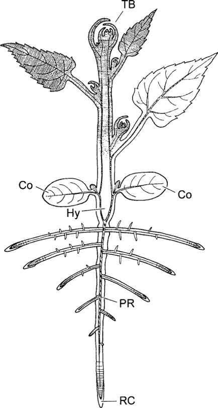

## Life history characters (add to botanical codex)

- **Annual**: completes life cycle in a single year
- **Biennial**: completes life cycle in two years
- **Perennial**: lives more than two growing seasons
- **Evergreen**: keeps its leaves year-round
- **Deciduous**: looses its leaves at the end of growing season
- **Hard to determine what a herbaceous plant is…**
  - annuals have small slender taproots, while biennials/perennials are larger.
  - biennials & perennials often have storage structures (bulbs)
  - plants with woody stems are perennials

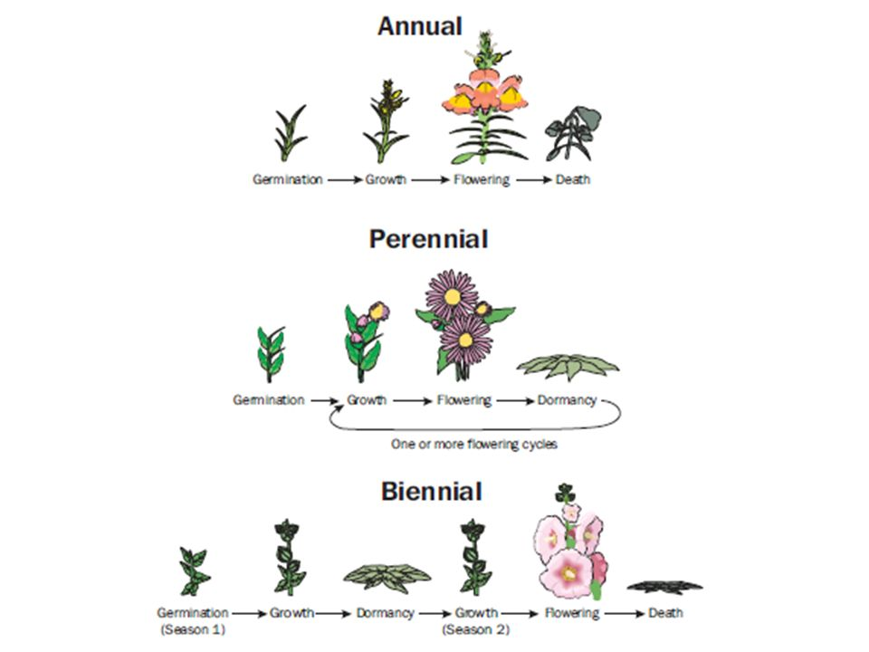

## Plant vegetative organs (add to botanical codex)

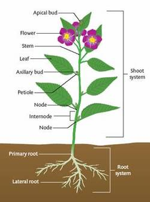

- **Root: anchor and absorbs, underground, develop from radicle in seed**
- **Leaf: photosynthetic organ, attached to stem, has a bud at its base**
- **Stem - leaf-bearing organ, with buds**
- **Some plants lack one or more of these structures**
  - aquatic plants often lack roots and cacti lack leaves.

## Leaf parts (add to botanical codex)

- **Blade - main photosynthetic part**
  - margins, veins and midrib all have character states
- **Petiole - a botany term for the stalk of the leaf**
  - presence, length, shape, surfaces are all character states
- **Stipules - appendage at base of petiole in some leaves**
  - protects young leaves
  - stipules can be glandular, leafy, spiny, or scale-like
  - often, stipules fall off after the leaf expands

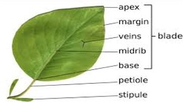

## Leaf structure (add to botanical codex)

- **Simple - One blade attached to a single petiole**
- **Compound - leaf blade divided into smaller sections (leaflet)**
  - leaflet - section of a compound leaf
- **Rachis - stalk that supports leaflets in a compound leaf**
  - continuation of the petiole into the blade
- **Pinnately compound - Leaflets arranged along both sides of a rachis**
- **Palmately compound - leaflets attached at one point at the end of the petiole**

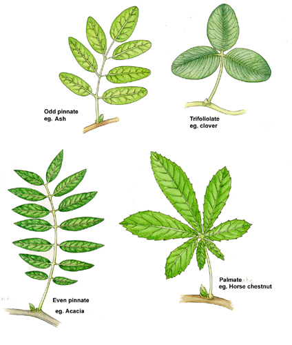

## Leaf Arrangement (add to botanical codex)

- **Leaves may be found at the base of the plant (e.g. dandelion), along the stem, or both**
- **Leaves are attached to the stem at *nodes*:**
1. alternate - one leaf per node
2. opposite - two leaves per node
3. whorled - more than two leaves per node; not common in temperate woody plants

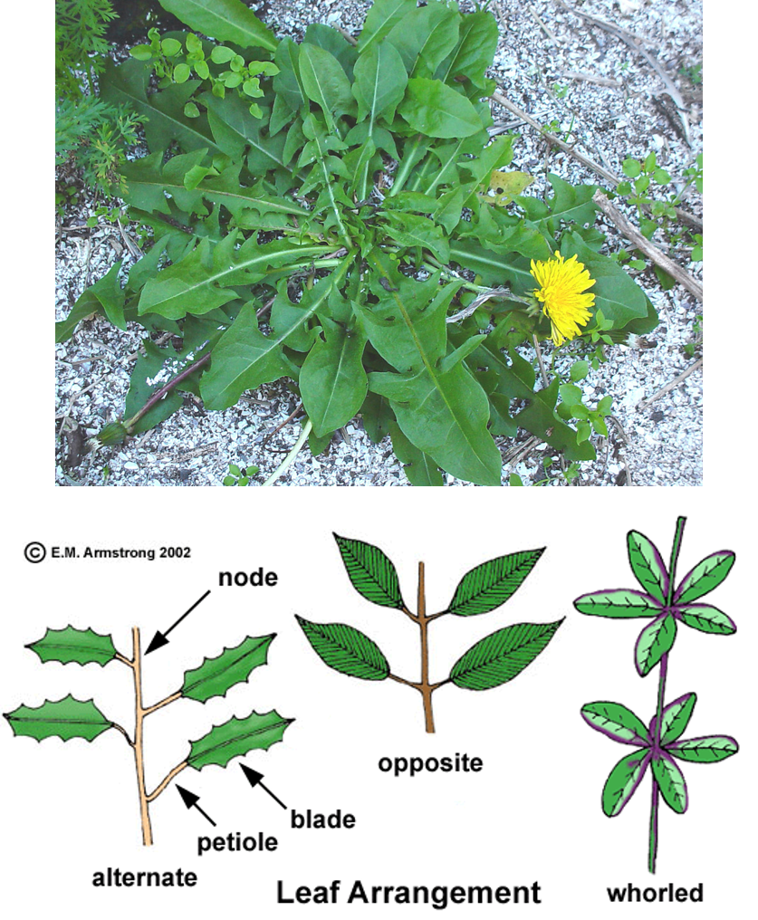

## Trees with opposite leaves = MADCAP HORSE

- **M=maple; A=ash; D=dogwood**
- **CAP=Caprifoliaceae or Honeysuckle family**
- **Horse = Horsechestnut and buckeye**
- **The core MADCAP HORSE species (Maple, Ash, Dogwood, Viburnum/Elderberry, Honeysuckle family, Buckeyes) are all represented in the Appalachian region**

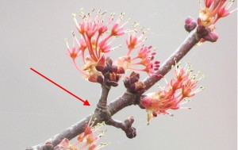

## Leaf margin (add to botanical codex to match your collection)

**COMMON FEATURES:**

- **Entire: margin smooth**
- **Lobed: margin with indentations**
- **Serrate: saw-like teeth pointing forward**
  - Singe or double toothed
- **Dentate: saw-like teeth pointing outward**
  - Singe or double toothed

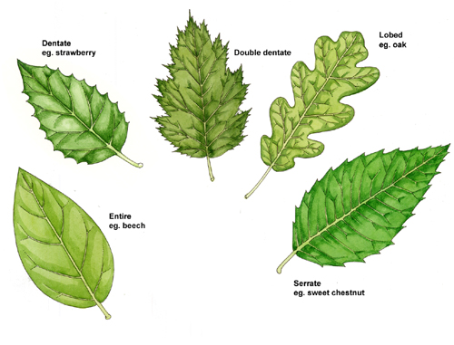

## Leaf shape: There are sooooo many

**add to botanical codex to match your collection**

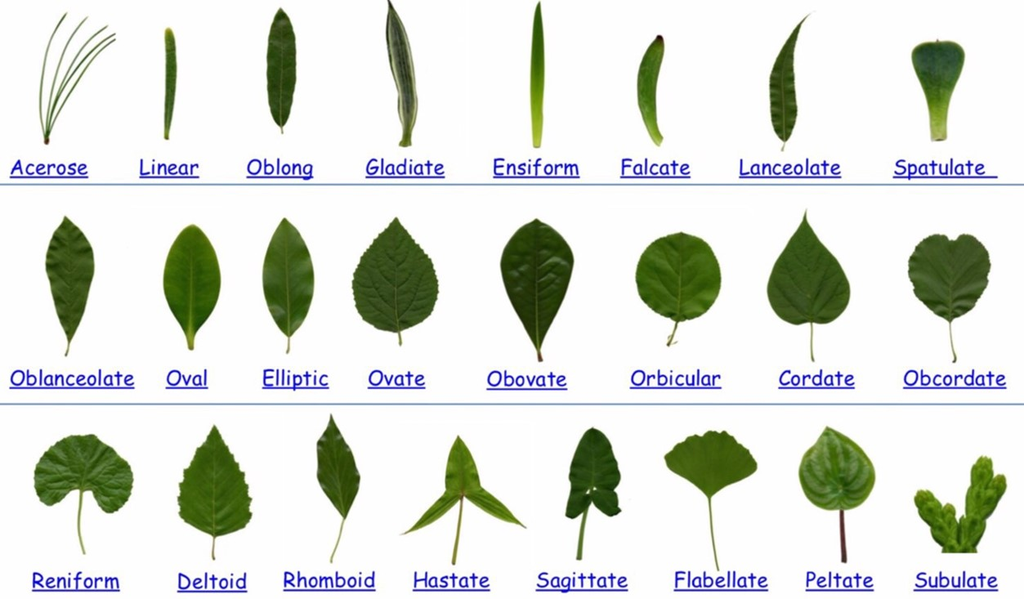

## Leaf Venation (add to botanical codex to match your collection)

**COMMON FEATURES:**

- **Parallel: primary & secondary veins parallel**
- **Reticulate (Netted): veins form a branching, web-like network across the leaf**
- **Pinnate: single main vein with secondary veins branching**
  - like a feather
- **Palmate: several primary veins arising from a one point**

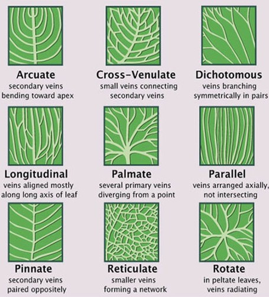

## Surface features (add to botanical codex)

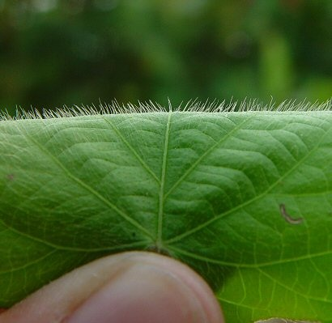

**COMMON FEATURES:**

- **glabrous - no hairs, smooth surface**
- **pubescent - hairy; due to trichomes**
- **glaucous - powdery covering**
- **scabrous - rough to the touch like sandpaper**

## Stem features

- **Node: region where leaf is attached**
  - internode - region between nodes
  - axil - upper junction of leaf and stem
- **Bud - embryonic shoot and/or flowers**
  - found in the leaf axil; at the base of leaf
  - axillary/lateral: buds along stem
  - terminal: buds at the end of the stem
  - scales: protective covering over bud
- **Terminal bud scale scar: left on stem where the terminal bud scales fell off**
  - marks where one year’s growth began
  - by counting the sets of bud scale scars down a stem, you can estimate the number of years of growth

[figure not shown]

## Know your bark!

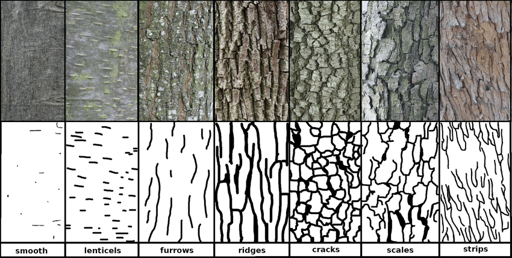

## Get collecting!!

- **50 pressed specimens**
  - plant presses must stay in SS 303
  - use ‘Seek’ app, ’Google Lens” or other to ID
    - verify with field guides in lab
    - always archive a picture
- **50 drawings in your field guide**
  - include a table of contents
  - add a character guide in your sketchbook
  - sketch each leaf and other characters
  - list the diagnostic characters
  - 2-3 ecological/cultural facts

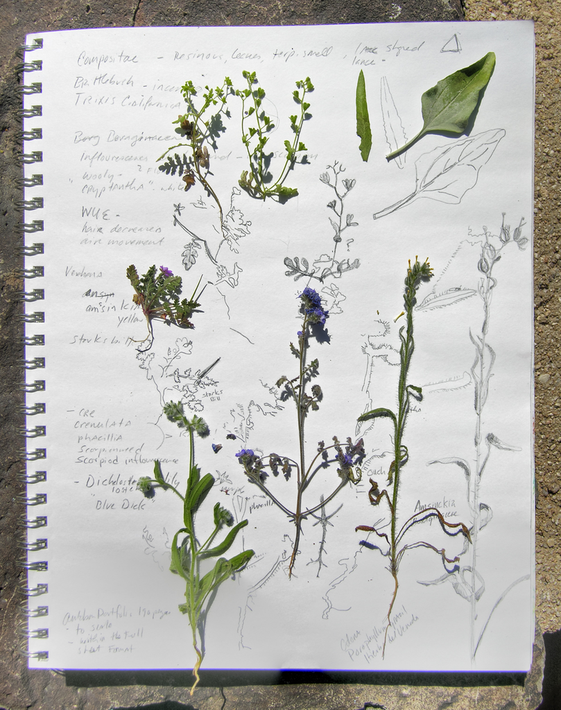

## Web Resources and Plant ID apps

https://dendro.cnre.vt.edu/dendrology/factsheets.cfm

https://gobotany.nativeplanttrust.org/simple/

http://www.southeasternflora.com/

https://dendro.cnre.vt.edu/dendrology/leafkey.htm

https://www.inaturalist.org/pages/seek_app

https://www.inaturalist.org/